# Linear models and ANOVA in R

Scientific workflows: Tools and Tips 🛠️

2026-12-17

## What is this lecture series?

### Scientific workflows: Tools and Tips 🛠️

📅 Every 3rd Thursday 🕓 4-5 p.m. 📍 Webex

- One topic from the world of scientific workflows
- Material provided [online](https://selinazitrone.github.io/tools_and_tips/)
- If you don’t want to miss a lecture
  - [Subscribe to the mailing list](https://lists.fu-berlin.de/listinfo/toolsAndTips)
- For credit points: Send me a short message (Email or Webex)

## Today: Linear models

#### How it works

- There’s a **GitHub repo** you download and open in your IDE
- I demonstrate each topic: **follow along in the scripts**
  - I will focus on explaining the statical code and concepts
  - I will assume you know R basics (data frames, pipes, ggplot2, …)
- Each part has a short **exercise** to try it yourself
- **Questions** anytime: in the chat or just unmute

## Get set up

1. Click the green **Code** button → **Download ZIP**
2. Unzip it somewhere you can find it
3. Double-click the `.Rproj` file → opens in RStudio
   - *(Positron/VS code users: open the folder)*
4. Run `install_packages.R` to install today’s packages (if you don’t have them yet)

Repo: https://github.com/selinaZitrone/lm-anova-workshop

# Statistical modelling

## An example

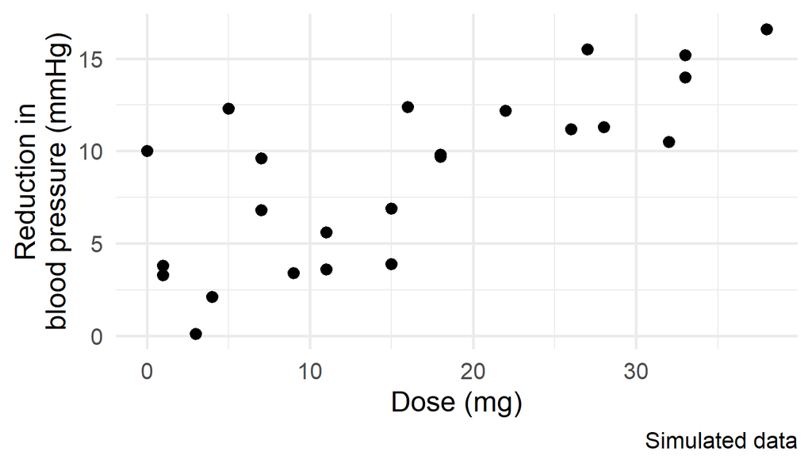

- Patients take **different doses** of a medication
- We measure **how much their blood pressure drops**

## Why do we model?

### Description

What is the **pattern** in our data?

*How much more did blood pressure drop per mg in our patients?*

### Inference

Is it **more than chance**, and how certain are we?

*Does a higher dose lower blood pressure more in patients in general?*

### Prediction

What do we **expect** for **new values**?

*How much will blood pressure drop for a new patient with 25 mg?*

## What is a model?

**Data = Model + Error**

- **Model**: describes the main pattern in the data
- **Error**: what the model doesn’t explain

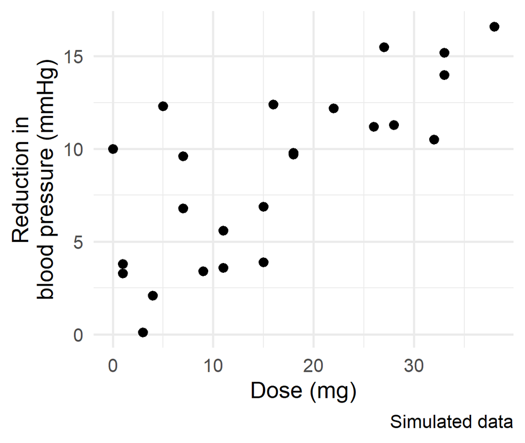

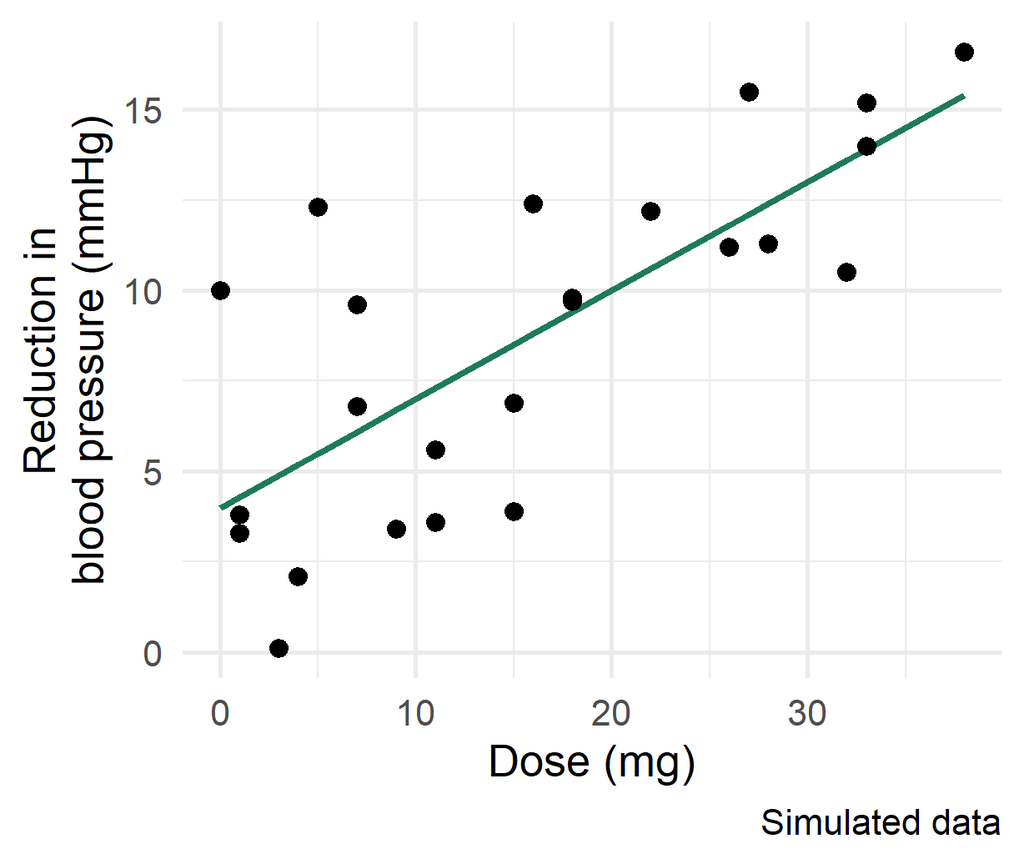

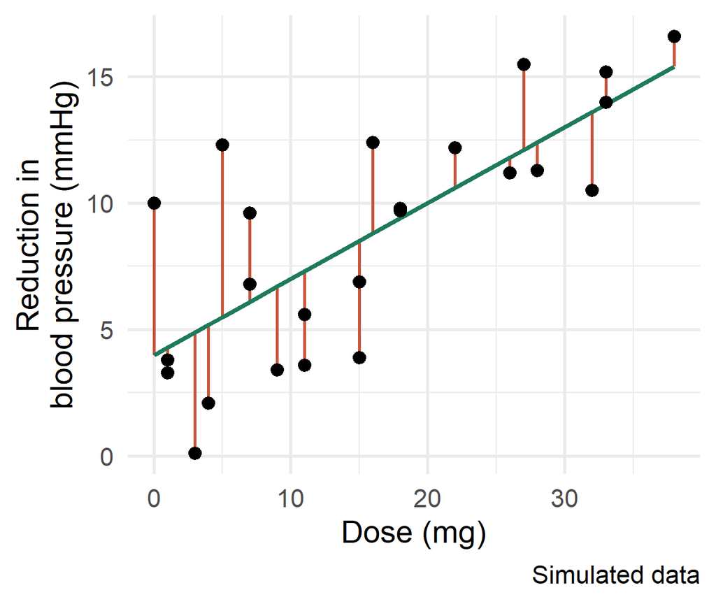

## Many models are possible

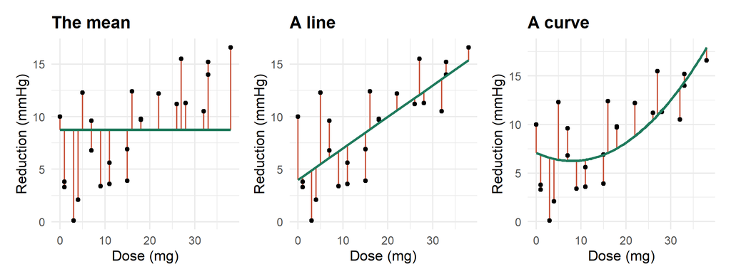

Which one do we choose?

- It depends on our **question** and what we **know** about the data
- As simple as possible, but it should describe the main pattern

# Linear models

## The `palmerpenguins` dataset

Data on 3 penguin species from Antarctica

```r
# install.packages("palmerpenguins")
library(palmerpenguins)
```

R package [`palmerpenguins`](https://allisonhorst.github.io/palmerpenguins/index.html), artwork by Allison Horst

## The `palmerpenguins` dataset

- 344 penguins from **three species**
- Each row is **one penguin**

```r
penguins
```

```
# A tibble: 344 × 8
   species island    bill_length_mm bill_depth_mm flipper_length_mm body_mass_g
   <fct>   <fct>              <dbl>         <dbl>             <int>       <int>
 1 Adelie  Torgersen           39.1          18.7               181        3750
 2 Adelie  Torgersen           39.5          17.4               186        3800
 3 Adelie  Torgersen           40.3          18                 195        3250
 4 Adelie  Torgersen           NA            NA                  NA          NA
 5 Adelie  Torgersen           36.7          19.3               193        3450
 6 Adelie  Torgersen           39.3          20.6               190        3650
 7 Adelie  Torgersen           38.9          17.8               181        3625
 8 Adelie  Torgersen           39.2          19.6               195        4675
 9 Adelie  Torgersen           34.1          18.1               193        3475
10 Adelie  Torgersen           42            20.2               190        4250
# ℹ 334 more rows
# ℹ 2 more variables: sex <fct>, year <int>
```

## What we do today

**Linear regression**

*How much heavier are penguins with longer flippers?*  
continuous predictor

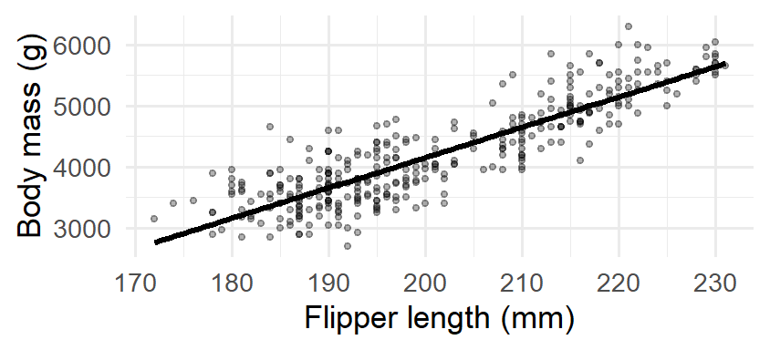

**ANOVA**

*How much does body mass differ between species?*  
categorical predictor

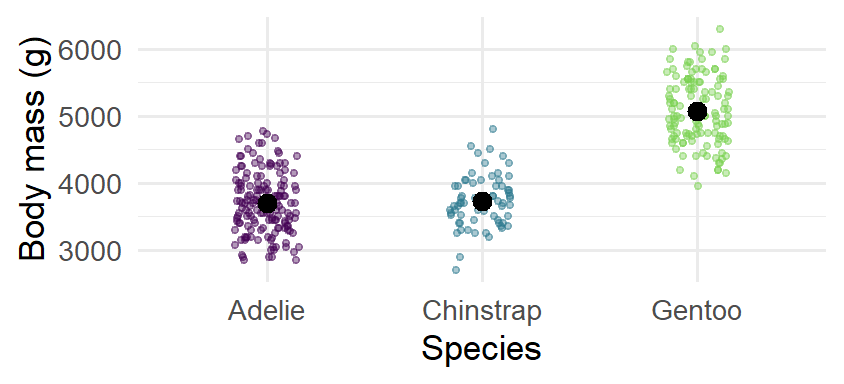

**ANCOVA**

*Does the relationship differ between species?*  
continuous and categorical predictor

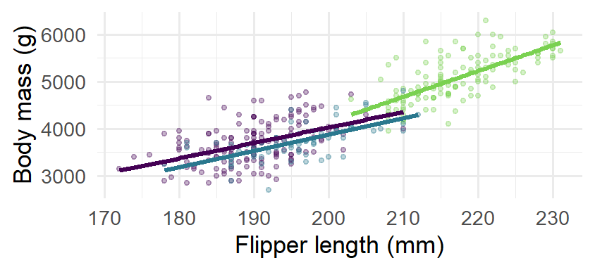

# Linear regression

> continuous predictor

## How much heavier are penguins with longer flippers?

- **Expectation:** Penguins with longer flippers are heavier
- **Question:** By how much, and how certain are we?

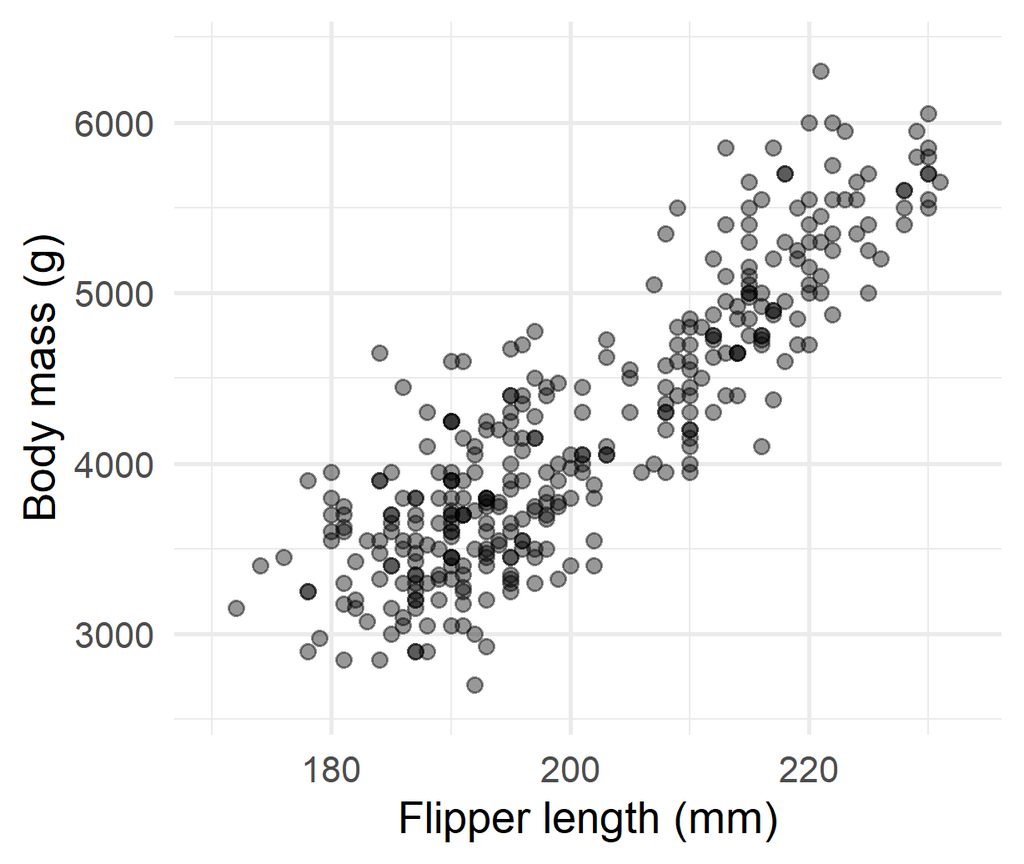

## The model

**Data = Model + Error**

y = β<sub>0</sub> + β<sub>1</sub> · x + ε

body mass = β<sub>0</sub> + β<sub>1</sub> · flipper length + ε

- **β<sub>0</sub>**: intercept, body mass at a flipper length of 0
- **β<sub>1</sub>**: slope, change in body mass per mm
- **ε**: error, what the model doesn’t explain

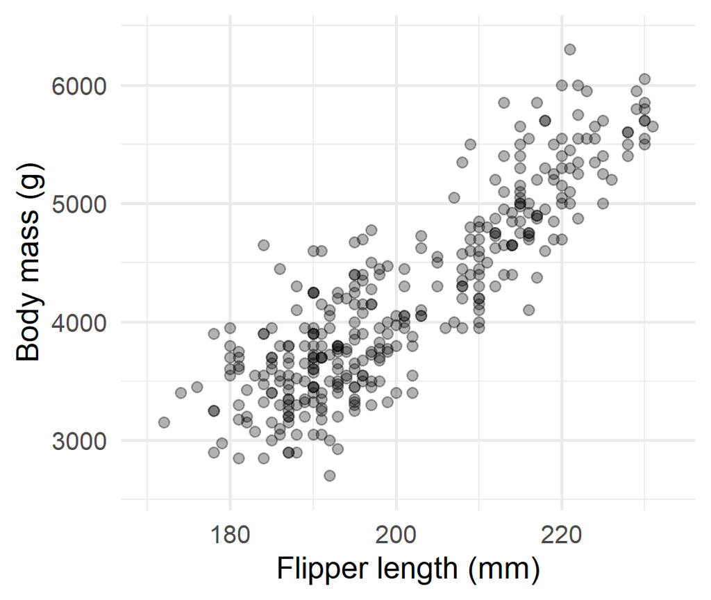

[figure not shown]

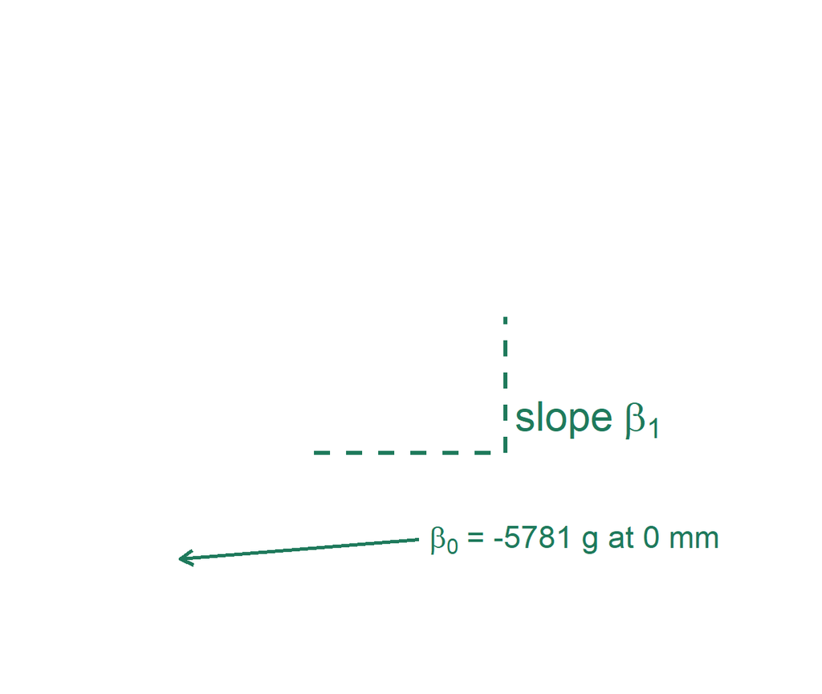

[figure not shown]

## Which model is best?

Many lines are possible

So how do we find the best one?

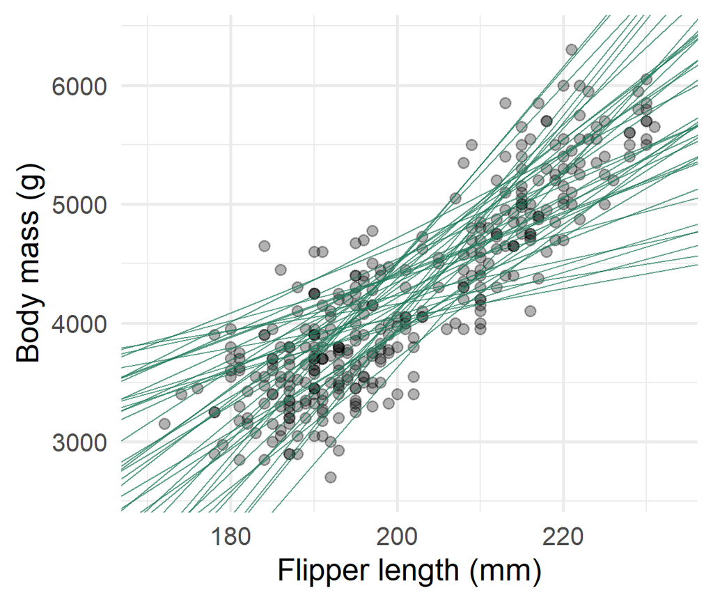

## The best line has the smallest residuals

**Model residuals**

$Y_i - \hat{Y}_i$

**Residual sum of squares (RSS)**

$RSS = \sum_{i=1}^{n} (Y_i - \hat{Y}_i)^2$

**Aim of model fitting:**  
Find model coefficients that lead to the lowest RSS  
(ordinary least squares, OLS)

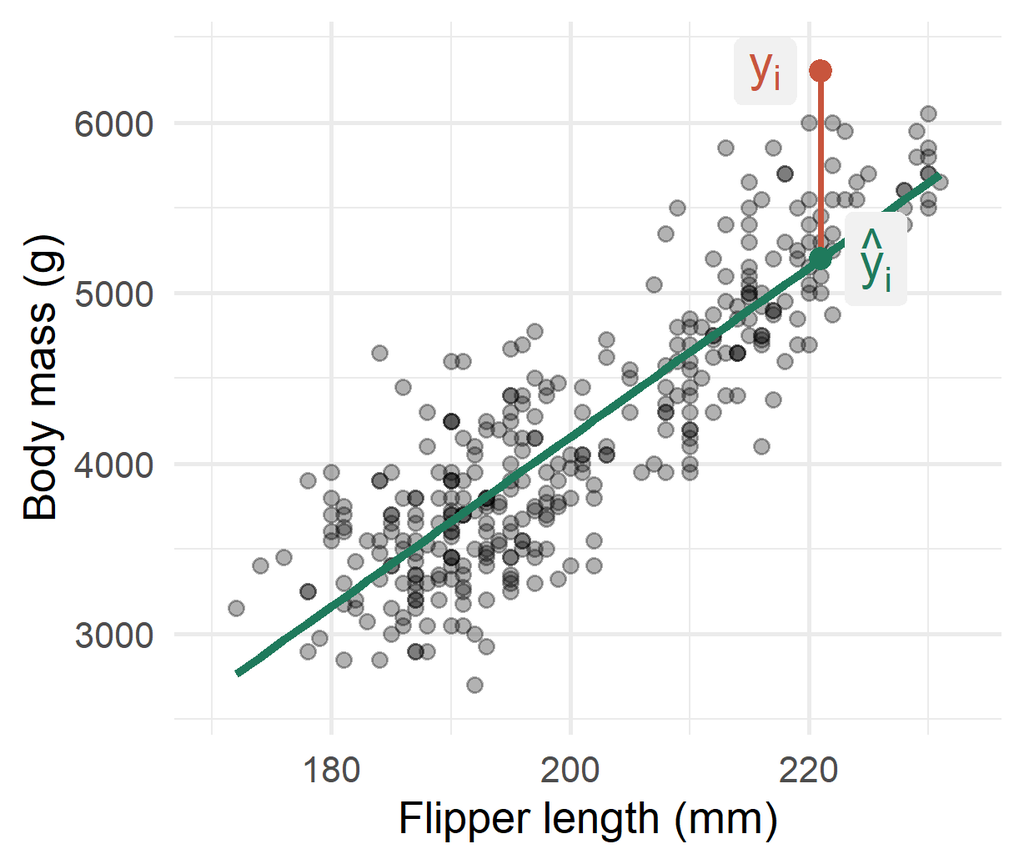

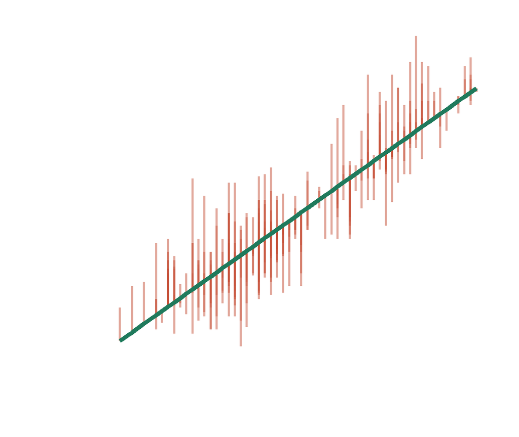

## When can we trust the results?

The model makes **assumptions**:

- The relationship is **linear**
- Residuals are **normally distributed** around the line
- Residual **variance is constant** along the line
- No strong **outliers**
- Observations are **independent** (study design!)

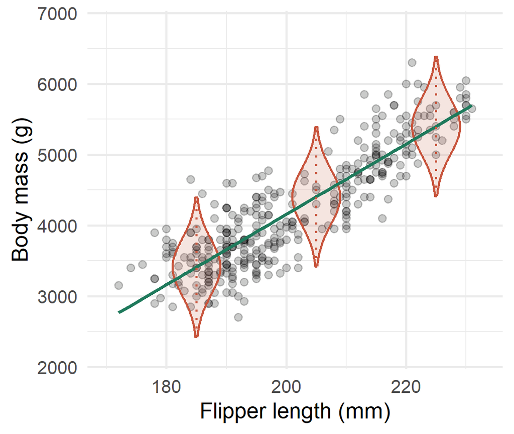

## Linear regression in R

Fit a linear model with `lm()`:

```
lm(
  formula = response ~ predictor,
  data = data
)
```

For our penguins:

```r
m_reg <- lm(
  body_mass_g ~ flipper_length_mm,
  data = penguins
  )
```

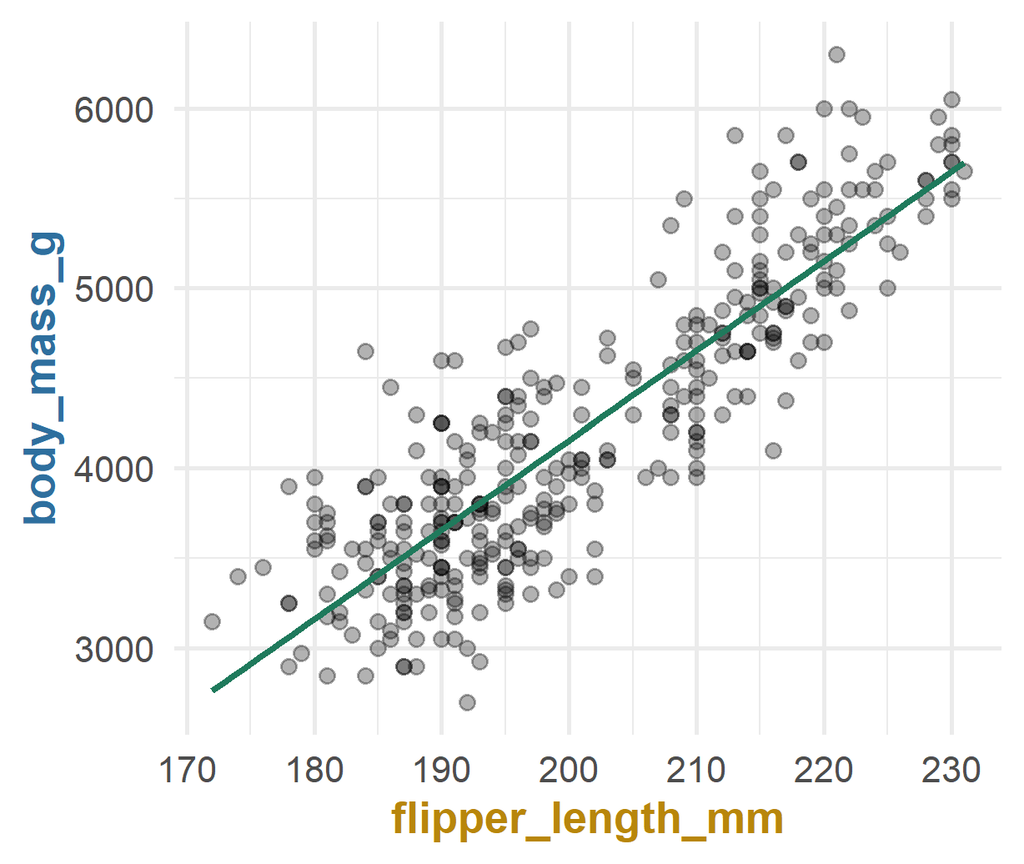

## Check the model assumptions

```r
performance::check_model(m_reg)
```

## Check the model assumptions

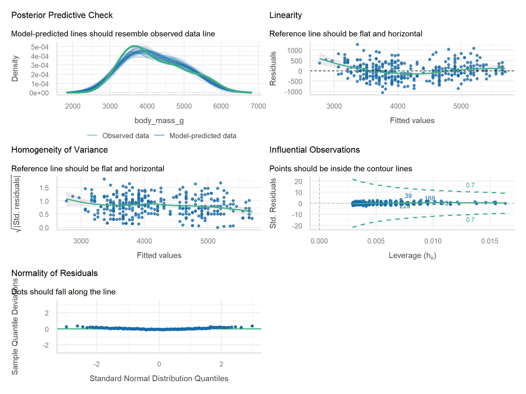

## Check the model assumptions

Look for **clear patterns**, not perfection

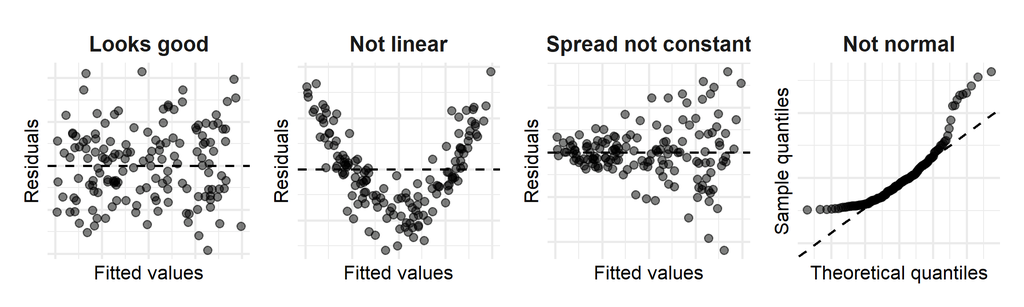

## How big is the effect?

```r
summary(m_reg)
```

```
Call:
lm(formula = body_mass_g ~ flipper_length_mm, data = penguins)

Residuals:
     Min       1Q   Median       3Q      Max
-1058.80  -259.27   -26.88   247.33  1288.69

Coefficients:
                   Estimate Std. Error t value Pr(>|t|)
(Intercept)       -5780.831    305.815  -18.90   <2e-16 ***
flipper_length_mm    49.686      1.518   32.72   <2e-16 ***
---
Signif. codes:  0 '***' 0.001 '**' 0.01 '*' 0.05 '.' 0.1 ' ' 1

Residual standard error: 394.3 on 340 degrees of freedom
  (2 observations deleted due to missingness)
Multiple R-squared:  0.759, Adjusted R-squared:  0.7583
F-statistic:  1071 on 1 and 340 DF,  p-value: < 2.2e-16
```

## Summary table

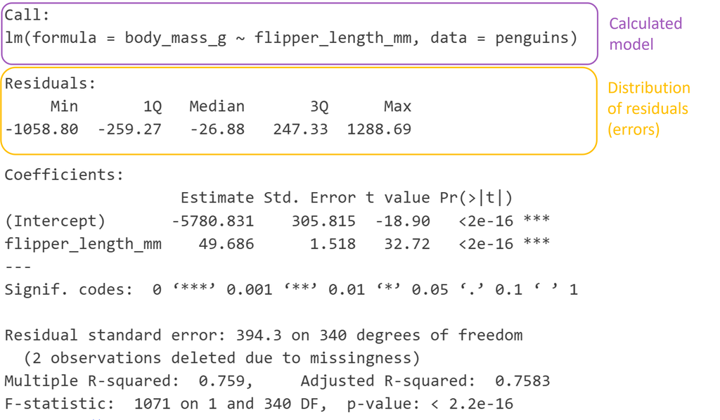

## Summary table: coefficients and effect size

[figure not shown]

- Per mm of flipper length, penguins are on average **49.7 g heavier**

## How precise is the estimate?

```r
confint(m_reg)
```

```
                        2.5 %      97.5 %
(Intercept)       -6382.35801 -5179.30471
flipper_length_mm    46.69892    52.67221
```

- Other samples would give slightly different slopes
- The **95% confidence interval (CI)** shows range of plausible values
- Slope: **46.7 to 52.7 g** per mm
- Intercept: not interesting here

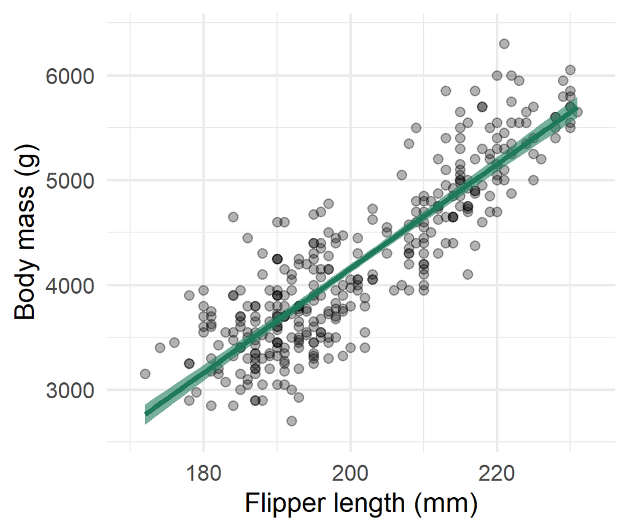

## How much evidence is there for an effect?

Is the effect we observe real or could it be due to chance?

Compare the **null model** (mean) with our **model** (line):

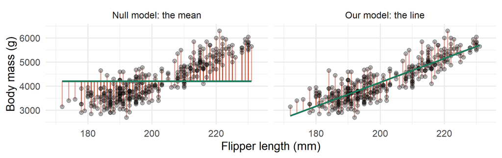

## How much evidence is there for an effect?

```r
car::Anova(m_reg)
```

```
Anova Table (Type II tests)

Response: body_mass_g
                     Sum Sq  Df F value    Pr(>F)
flipper_length_mm 166452902   1  1070.7 < 2.2e-16 ***
Residuals          52854796 340
---
Signif. codes:  0 '***' 0.001 '**' 0.01 '*' 0.05 '.' 0.1 ' ' 1
```

- `flipper_length_mm`: how much the regression reduces the RSS compared to the mean
  - if p < 0.05, the effect is significant
- `Residuals`: what’s left over, the RSS of our model

Result: Strong evidence of an effect (F = 1071, p < 0.001).

## How much variance does the model explain?

Get the R-squared values from the summary table (bottom)

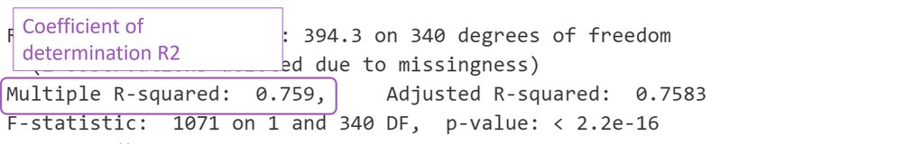

- R² = 1 − RSS(model) / RSS(null model)
  - share of variation explained by the model (0 = no better than mean, 1 = perfect fit)
- Adjusted R²: corrected for the number of predictors. Use it to compare models.

Result: Flipper length explains 76% of the variation in body mass (R² = 0.76).

## Show the model

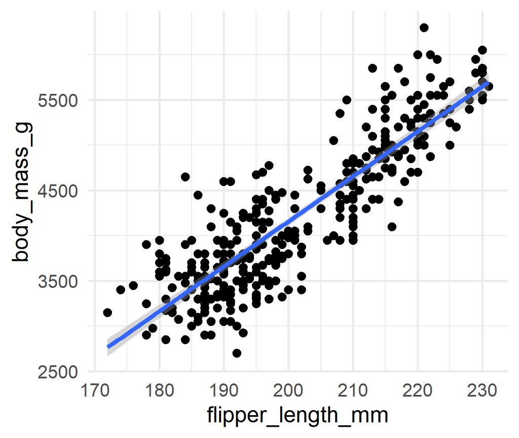

```r
ggplot(
  penguins,
  aes(x = flipper_length_mm, y = body_mass_g)
) +
  geom_point() +
  geom_smooth(method = "lm")
```

- `geom_smooth(method = "lm")` fits the same model and shows the 95% CI of the line

## Plot the model with `augment()`

`broom::augment()` adds fitted values and confidence intervals to the data:

```r
# step 1: add fitted values and confidence intervals to the data
pred <- augment(m_reg, interval = "confidence")
pred
```

```
# A tibble: 342 × 11
   .rownames body_mass_g flipper_length_mm .fitted .lower .upper  .resid    .hat
   <chr>           <int>             <int>   <dbl>  <dbl>  <dbl>   <dbl>   <dbl>
 1 1                3750               181   3212.  3139.  3285.  538.   0.00881
 2 2                3800               186   3461.  3400.  3522.  339.   0.00622
 3 3                3250               195   3908.  3862.  3953. -658.   0.00344
 4 5                3450               193   3808.  3760.  3857. -358.   0.00385
 5 6                3650               190   3659.  3606.  3713.   -9.43 0.00469
 6 7                3625               181   3212.  3139.  3285.  413.   0.00881
 7 8                4675               195   3908.  3862.  3953.  767.   0.00344
 8 9                3475               193   3808.  3760.  3857. -333.   0.00385
 9 10               4250               190   3659.  3606.  3713.  591.   0.00469
10 11               3300               186   3461.  3400.  3522. -161.   0.00622
# ℹ 332 more rows
# ℹ 3 more variables: .sigma <dbl>, .cooksd <dbl>, .std.resid <dbl>
```

- `.fitted`: fitted values (on the line)
- `.lower` and `.upper`: 95% CI of the fitted values

## Plot the model with `augment()`

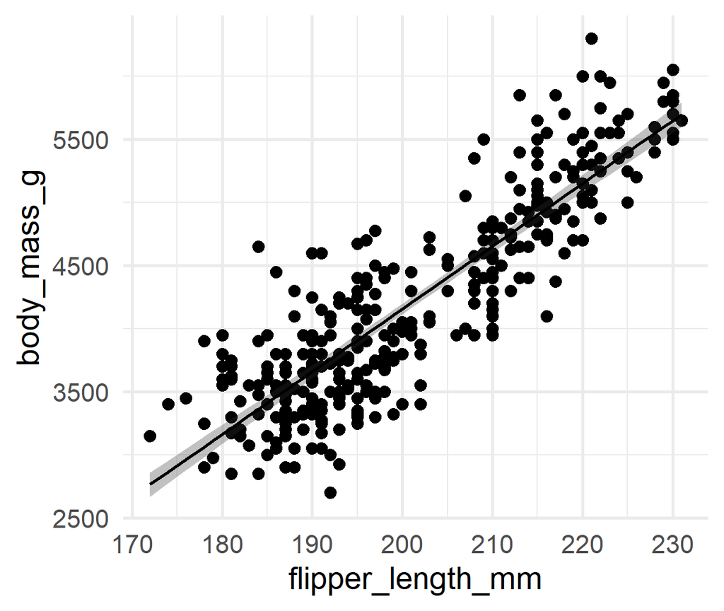

```r
# step 2: plot the data, fitted values and CI
ggplot(
  pred,
  aes(x = flipper_length_mm, y = body_mass_g)
) +
  geom_point() +
  geom_ribbon(
    aes(ymin = .lower, ymax = .upper),
    alpha = 0.3
  ) +
  geom_line(aes(y = .fitted))
```

- Advantage: Always plot your model, even if `geom_smooth()` does not work

## Predict new values with `augment()`

```r
# Create a new data frame with the values you want to predict
new_data <- tibble(flipper_length_mm = 200)
# predict using the model (convidence interval)
augment(m_reg, newdata = new_data, interval = "confidence")
```

```
# A tibble: 1 × 4
  flipper_length_mm .fitted .lower .upper
              <dbl>   <dbl>  <dbl>  <dbl>
1               200   4156.  4114.  4198.
```

```r
# predict using the model (prediction interval)
augment(m_reg, newdata = new_data, interval = "prediction")
```

```
# A tibble: 1 × 4
  flipper_length_mm .fitted .lower .upper
              <dbl>   <dbl>  <dbl>  <dbl>
1               200   4156.  3380.  4933.
```

- **Confidence interval**: mean of all penguins with 200 mm flippers
- **Prediction interval**: body mass of one new penguin. Wider, because it includes individual variation between penguins
- Note: Only predict within the range of the data (172–231 mm)

## Report the results

A result in a paper could look like this:

> Body mass increased by **49.7 g per mm** of flipper length (95% CI 46.7–52.7; F<sub>1,340</sub> = 1070.7, p < 0.001, R² = 0.76).

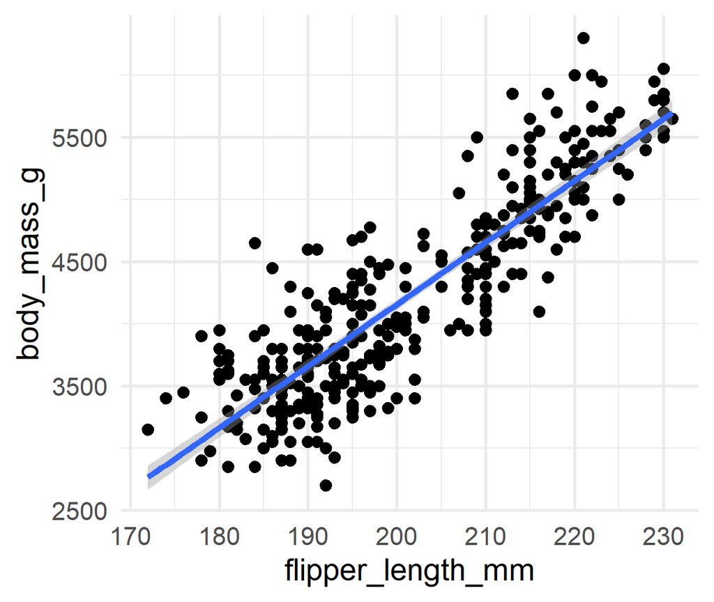

Always report the **size** of the effect and its **uncertainty**, not only the p-value

## Linear model step by step

| Step | Linear regression |
| --- | --- |
| **Question** | How much heavier are penguins with longer flippers? |
| **Fit model** | `lm(body_mass_g ~ flipper_length_mm, data = penguins)` |
| **Check assumptions** | `performance::check_model()` |
| **Answer** | Effect size? `summary()`; How precise? `confint()`; How much evidence? `car::Anova()`; How much variation? `summary()` R² |
| **Show** | `geom_smooth(method = "lm")` or `augment()` |
| **Report** | Effect, 95% CI, F, p, R² |

## Your turn

> ✏️ **Exercise 1 (~10 min):**

> Open `exercises/01_regression_exercise.R`

# ANOVA

> categorical predictor

## How much does body mass differ between species?

- **Expectation:** Gentoo penguins are heavier
- **Question:** Which species differ, and by how much?

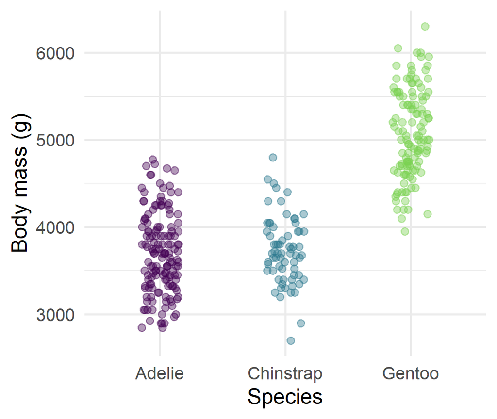